# Forest type and height are important in shaping the altitudinal change of radial growth response to climate change | Scientific Reports

# Forest type and height are important in shaping the altitudinal change of radial growth response to climate change

- Penghong Liang,
- Xiangping Wang,
- Han Sun,
- Yanwen Fan,
- Yulian Wu,
- Xin Lin &
- Jinfeng Chang

[*Scientific Reports*](https://www.nature.com/srep) **volume 9**, Article number: 1336 (2019) Cite this article

## Abstract

Tree radial growth is widely found to respond differently to climate change across altitudinal gradients, but the relative roles of biotic factors (e.g. forest type, height and density) vs. climate gradient remain unclear. We sampled tree rings from 15 plots along a large altitudinal gradient in northeast China, and examined how climate gradient, forest type, height, tree size and density affect: (1) temporal growth variability [mean sensitivity (MS) and standard deviation (SD) of the chronologies], and (2) the relationship of ring width indices (RWI) with historical climate. We used BIC based model selection and variable importance to explore the major drivers of their altitudinal patterns. The results showed that: both growth variability and RWI-climate relationships changed significantly with altitude. Forest height was the most important predictor for altitudinal changes of MS and SD. For RWI-climate relationships, forest type was more important than climate gradient, while height and stem density were weak but necessary predictors. We showed that the altitudinal difference in growth response to climate change cannot be explained by climate gradient alone, and highlight the necessity to examine the influence of biotic factors (which covary with climate across geographic gradient) to better understand forest response to climate change.

## Introduction

The world is undergoing rapid climate change<sup>1</sup>, and forest growth has been widely reported to respond to climate change differently across climatic gradients<sup>2,3,4</sup>. Understanding the drivers of these different responses is critical for predicting forest dynamics under future climate and to develop adaptive strategies<sup>4,5,6</sup>, especially when climate change has reduced tree productivity and survival in many regions of the world<sup>7,8</sup>.

Altitudinal gradients are ideal places to examine the different response of tree growth to climate change across environmental gradients. Many studies have found that the relationship between ring width indices (RWI) and climate varies with altitude (e.g. ref.<sup>9,10,11</sup>) and latitude<sup>2,12,13</sup>. However, many studies have included only one forest zone or examined the different growth response of a single species across elevations (e.g. ref.<sup>10,14,15,16</sup>). Consequently, the altitudinal change of RWI-climate relationship was generally explained as a result of different climate at different elevations. However, large altitudinal gradients generally cover different forest zones. This is similar to the latitudinal gradient and thus more useful in understanding the different growth response to climate change at broad scales. Other studies have found that different forest types (species) under a similar climate may show contrasting growth response to climate change, suggesting that species identity is another key factor leading to different growth response<sup>4,11,17,18</sup>. Thus, different forest types distributed along elevational gradients may contribute to the altitudinal change of RWI-climate relationship, but its relative effect vs. climate gradient has not been well quantified.

In addition to forest type, other biotic factors may also influence the growth response to climate change. For example, greater tree height leads to greater difficulty in transporting water from root to canopy<sup>19,20</sup>, thus the growth of taller trees may be more sensitive to water deficit than small trees under the same climate condition. Consistent with this prediction, some studies have found that the growth of larger-DBH or older trees (which were generally taller trees) were more sensitive to climate change<sup>6,21,22</sup>. Meanwhile, tree density was also found to have significant influence on growth sensitivity to water deficit (e.g. ref. <sup>6</sup>). Tree height and stem density are widely observed to change markedly with altitude and latitude<sup>23,24,25,26</sup>. Thus the changes of RWI-climate relationship may not be the sole result of climate gradient and different forest types across latitude (altitude), tree height, size and density may also play a significant role. Here we tested this hypothesis along a large altitudinal gradient.

While most studies have focused on the altitudinal pattern of the growth-climate relationship, another important aspect of growth response to climate change, i.e. temporal growth variability, has remained less examined. Studies have found that chronology statistics, e.g. mean sensitivity (MS) and standard deviation (SD), also changed across altitudes<sup>14,16,27</sup>. MS is a measure of year-to-year growth variability, and is commonly accepted to reflect the growth sensitivity to high-frequency variation in climate. Meanwhile, SD reflects the multi-decadal growth variability in a chronology, which was related to the low-frequency fluctuation in climate<sup>28,29</sup>. Thus, the altitudinal changes of MS and SD can provide valuable information on how growth response to climate change varies along altitudinal gradients. However, the two metrics have largely been used as indicators of chronology quality in many studies, and the abiotic and biotic drivers for their geographic patterns have been less explored<sup>30,31</sup>. Consequently, a second aim of our study is to examine this question. Meanwhile, RWI-climate relationship and growth variability are distinctive aspects of growth response to climate change. Thus the relative roles of climate, forest type, height and stem density on their altitudinal patterns are expected to be different. A third aim of this analysis is to examine how the abiotic and biotic drivers differ between growth variability and RWI-climate relationship.

We sampled tree rings from 15 plots along the altitudinal gradient of Mt. Changbai to examine the drivers of different growth response to climate change. Specifically, we asked three questions as follows. (1) How does RWI-climate relationship and growth variability change across different forest types along the altitudinal gradient? (2) Does biotic factors (including forest type, height, size and density) affect the altitudinal change of RWI-climate relationship and growth variability? (3) What are the differences in the abiotic and biotic drivers between RWI-climate relationship and growth variability?

## Materials and Methods

### The study area

Mt. Changbai (41°43′–42°26′N, 127°42′–128°17′E) is situated at the southeast border of Jilin Province, northeast China. The climate in this region is characterized by warm summers, cold winters, abundant precipitation and a short growing season, largely controlled by the East Asian monsoon. With increasing altitude from mountain foot to top, mean annual temperature decreases from 4.9 to −7.3 °C and mean annual precipitation increases from 600 to 1340 mm<sup>32</sup>. As a result, different forest zones are distributed along the altitudinal gradient of Mt. Changbai. (1) 500–1100 m: Korean pine and broadleaf mixed forest (KBF), dominated by *Pinus koraiensis* and mixed with broadleaf species, such as *Quercus mongolica*, *Tilia* spp. In this forest zone there are also secondary forests of KBF, e.g. *Betula platyphylla* forests (BPF). (2) 1100–1700 m: evergreen needle-leaved forest (ENF), composed of *Picea jezoensis* and *Abies nephrolepis*; and deciduous needle-leaved forest (DNF) dominated by *Larix olgensis*. (3) 1700–2000 m: *Betula ermanii* forest (BEF)<sup>33</sup>. Thus, the mountain provided an idea place to examine the abiotic and biotic drivers for altitudinal change of growth response to climate change.

### Field sampling and chronology development

[Full size table](https://www.nature.com/articles/s41598-018-37823-w/tables/1)

### Climate data

Monthly climate data between 1959 and 2005 of the Erdao meteorological station, at the foot of Mt. Changbai (591 m), were obtained from the China National Climatic Data Center (http://data.cma.cn/). Our plots differed greatly in altitude and thus, for a better analysis of the growth-climate relationship, we estimated the historical monthly climate for each plot. For altitudinal changing rates of monthly mean temperature and total precipitation (see Supplementary Table S1), we used the model of Wang *et al*.<sup>38</sup>. The model was developed based on 48 climate stations in the Mt. Changbai region (including the Tainchi station at the mountain top, 2623 m), and has been calibrated by independent climate data which showed that the model was accurate enough (the *R*<sup>2</sup> between the estimated and measured values was 0.83 for temperature and 0.79 for precipitation, respectively)<sup>38</sup>. For each plot, the climate variables in each month by each year (1959 to 2005) were estimated based on the altitudinal changing rates of temperature and precipitation in Supplementary Table S1. Then the RWI of the plot was related to these monthly climate variables to examine the growth response to climate change (see Supplementary Table S2).

We also calculated the multi-decades means of monthly temperature and precipitation for each plot, which were then used to calculate climate indices such as actual evapotranspiration (AET), mean annual temperature and precipitation, mean temperature for the coldest month, etc. These multi-decades mean climate indices were used to depict the climate condition of each plot, in order to evaluate the relative effect of climate gradient vs. biotic factors (e.g. forest type and height) on altitudinal patterns of growth response to climate change.

### Statistical analyses

We used MS and SD of the chronologies as indicators of temporal growth variability of radial growth. For growth-climate relationship, we related RWI of each plot to monthly temperature and precipitation from June of the previous year through September of the current year (Supplementary Table S2). Because we are interested in the abiotic and biotic drivers for the altitudinal change of RWI-climate relationship, we selected some correlations for further statistical analyses based on two criterions: (1) the correlation should show significant change with altitude (*P* < 0.05); (2) the monthly climate variable should have significant correlation (*P* < 0.05) with RWI in at least three plots. As a result, the following correlations were selected: the correlation of RWI with temperature and precipitation of current June and previous July (Cor_c6T, Cor_c6P, Cor_p7T and Cor_p7P, respectively), and the RWI correlation with current July temperature (Cor_c7T) and previous June precipitation (Cor_p6P). We also conducted a principal component analysis (PCA) to check the results (Supplementary Fig. S1), using the correlations between RWI and monthly climate variables of the 15 chronologies. The PCA1 loadings of the 15 plots were highly correlated with elevation (*r* = 0.84, *P* < 0.001), suggesting that PCA1 can well reflect the altitudinal patterns of RWI-climate correlations. As shown in Supplementary Fig. S1, the PCA1 scores (absolute value) were the highest for Cor_p7T, Cor_c6T, and Cor_c7T (Supplementary Fig. S1b), and Cor_p6P, Cor_p7P and Cor_c6P (Supplementary Fig. S1c). Thus the PCA results confirmed that the correlations we selected were major components of altitudinal change of growth response to climate change, and are well suited for our purpose. While there were still some other significant correlations in Supplementary Table S2, they did not reveal clear altitudinal patterns or occurred in only one or two plots. These correlations may be caused by local abiotic and biotic factors specific to the plots, which were not our focus and not further analyzed.

To identify the most important factors affecting growth variability and RWI-climate relationships, we first used the model selection approach based on Bayesian Information Criterion (BIC) to obtain the most parsimonious model, which is more conservative in retaining variables than commonly used Akaike Information Criterion (AIC)<sup>43</sup>. In a next step, we evaluated the relative importance of each variable retained in the final model, using the R package of “relaimpo 2.2–2”<sup>44</sup>. The package adopts the “LMG” approach to yield natural decompositions of model *R*<sup>2</sup> in regression models<sup>45</sup>. This approach clearly identifies a variable’s contribution by itself and in combination with all other predictors<sup>46</sup>, and thus, has been not only recommended by statisticians because it is superior to other importance metrics, but also increasingly used in ecological studies<sup>44,46,47</sup>.

## Results

### Altitudinal patterns of growth variability and growth-climate relationship

**Figure 1**

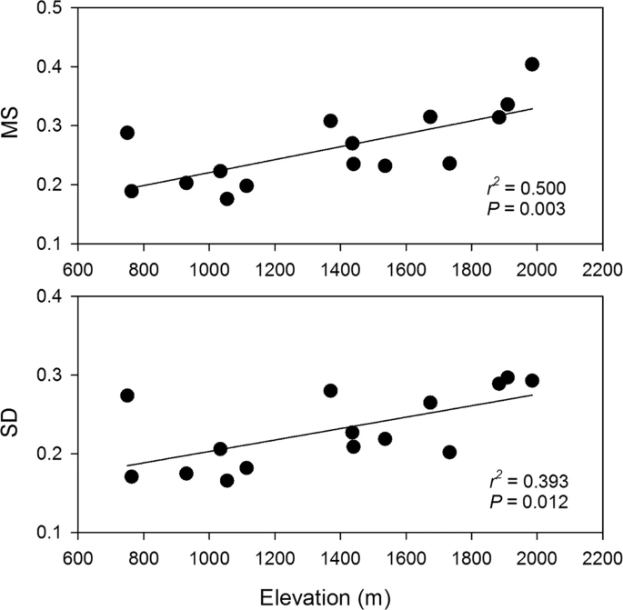

Changes of two chronology statistics, i.e. mean sensitivity (MS) and standard deviation (SD), for 15 plots along the altitudinal gradient of Mt. Changbai.

[Full size image](https://www.nature.com/articles/s41598-018-37823-w/figures/1)

**Figure 2**

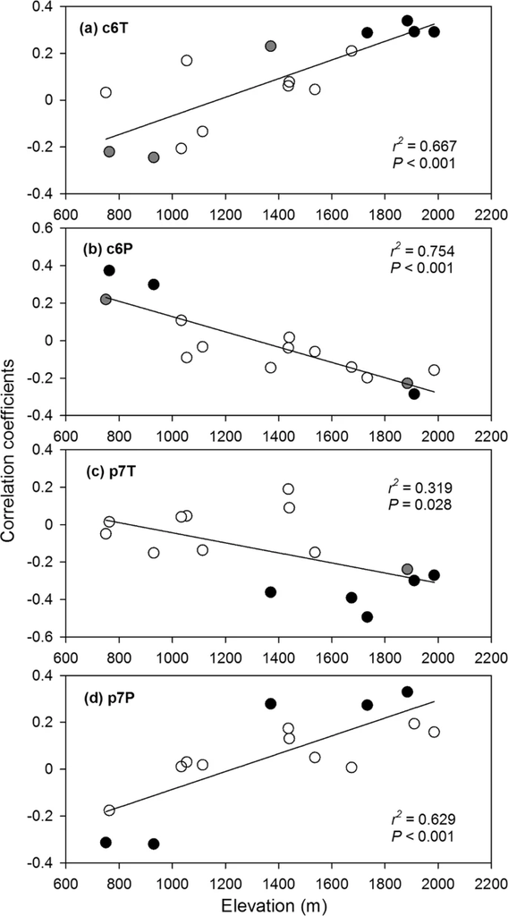

Changes of correlations between ring-width indices and some monthly climate variables along altitudinal gradient. (**a**) Temperature of the current June (c6T). (**b**) Precipitation of the current June (c6P). (**c**) Temperature of the previous July (p7T). (**d**) Precipitation of the previous July (p7P). Black dotes denote RWI-climate correlations with *p* values < 0.05; grey dots, *p* < 0.1; Circles, *p* > = 0.1.

[Full size image](https://www.nature.com/articles/s41598-018-37823-w/figures/2)

### Drivers for altitudinal patterns of growth variability and growth-climate relationships

[Full size table](https://www.nature.com/articles/s41598-018-37823-w/tables/2)

[Full size table](https://www.nature.com/articles/s41598-018-37823-w/tables/3)

[Full size table](https://www.nature.com/articles/s41598-018-37823-w/tables/4)

## Discussion

### Altitudinal patterns of growth variability and its drivers

Previous tree-ring studies along geographic gradients generally focus on the change of RWI-climate relationship, instead of the temporal growth variability during climate change. Our study sampled 15 plots across a large altitudinal gradient from temperate to timberline forests. We showed that growth variability (MS and SD) increased at higher altitude on humid mountains, even when different altitudinal zones were included (Fig. 1). Previous studies have noticed that MS and SD changes with altitude. In humid regions MS and SD were generally found to be higher with increasing altitudes<sup>14,16,48</sup>, while the converse altitudinal pattern was commonly observed in arid regions<sup>10,27,49</sup>. This difference is generally explained by the fact that: in arid regions, the water deficit at low altitudes is critical in limiting radial growth, but the stress is alleviated at higher altitudes and thus growth variability is lower<sup>14,27</sup>. Thus, the two contrasting altitudinal patterns are actually consistent, in that MS and SD are higher under harsher climate<sup>28</sup>. In addition to changes along altitude, other studies also found that MS and SD differed markedly among forest types (species) under similar climate (e.g. ref.<sup>21</sup>). For instance, Liang *et al*.<sup>18</sup> found that MS and SD decrease from early- to late-successional forests in a same site in northeast China. These results suggest that species identity may be another important factor affecting MS and SD in addition to environmental condition.

As for why growth variability (MS and SD) is negatively related to forest height, we hypothesis that this is because radial growth will show higher variability when productivity is lower. Forest height is well known to be higher in more productive sites (e.g. ref.<sup>23,25,53,54</sup>), consequently MS and SD are negatively related to tree height (size). Both forest productivity and height decrease with higher altitude on humid mountains but increased on mountains in arid regions. Consequently, MS and SD increased with higher altitude on humid mountains (e.g. this study and ref.<sup>14</sup>) but decreased on arid mountains<sup>27</sup>. This hypothesis may also explain why forest height is a better predictor in our study. Forest productivity is affected by a number of factors in addition to climate, e.g. soil fertility and local topography. Meanwhile, forest height is also affected by both these local factors and climate, and thus may a better indicator of productivity than climate indices. Along successional series, forest productivity generally increases from early- to late-successional stages (e.g. ref.<sup>55</sup>), and forest height also increases towards late-successional forests<sup>18,41</sup>. According to our hypothesis, MS and SD should be lower in later-successional forests, and thus lead to a negative relationship of MS and SD with forest height. This prediction is consistent with the findings in Liang *et al*.<sup>18</sup>. Meanwhile, larger-DBH trees (i.e. taller trees) commonly have higher productivity than smaller-DBH (e.g. ref.<sup>55</sup>). Consequently, smaller-DBH trees are expected to have higher MS, which has been reported in previous studies<sup>21,51,52</sup>. Thus, our hypothesis seems to provide an explanation for different situations (altitudinal gradients in humid and arid regions, successional series and different tree sizes).

However, the above-mentioned hypothesis and still needs further tests. Geographic patterns of MS and SD seem to be related to a number of abiotic and biotic factors, such as temperature gradient, water availability, tree size, age and species identity etc. (e.g. ref.<sup>21,28,56</sup>). Height is a key dimension of tree size, and is closely related to not only DBH and tree age but also productivity. Thus in theory height ought to have a critical in affecting the growth response to climate change. We suggest that more studies are needed to test the relative influence of tree height, age, species identity and climate, for a better understanding of temporal growth variability under climate change.

### Drivers for altitudinal change of growth-climate relationship

Many studies have reported that RWI-climate relationship changes along altitudinal gradients. Summer temperature was generally found to be the limiting climate factor of tree growth at high altitudes, while water-availability was the limiting factor at low elevations<sup>9,10,11,14,57</sup>. Our results on the altitudinal change of RWI-climate correlations are generally consistent with these previous findings. For instance, RWI was positively related to current June and July temperature in high-elevation plots (Fig. 2), consistent with the “growth limitation hypothesis” that growth of timberline forests is limited by growing season temperature<sup>58,59</sup>. At low altitudes, RWI was positively related to current June precipitation while negatively related to current June temperature, a typical indication that water availability is limiting for radial growth (e.g. ref.<sup>13,57</sup>). This limiting effect disappeared towards high altitude, which is a commonly-reported pattern because of increased precipitation and decreased temperature with higher altitude<sup>9,10,16</sup>. Influence of previous summer climate on current year growth (i.e. the lag effect) is evident in our study. Interestingly, previous and current summer climate showed not only contrast effect on growth but also converse altitudinal pattern (Fig. 2c,d). Similar contrast effects of current and previous summer climate on radial growth have also been found in previous studies in humid regions (e.g. ref.<sup>18,48</sup>), and is generally interpreted by the fact that rapid growth in the current year will reduce the nutrients stored in trees that can be used for next year growth<sup>28,56</sup>.

## Conclusion

In summary, our study showed that both growth variability and RWI-climate relationships varied regularly across different forest types along an altitudinal gradient in northeast China. We also examined the relative importance of climate, forest type, height and density in shaping these altitudinal patterns (probably the first one along altitudinal gradients). We showed that forest height is the most important predictor for MS and SD, while forest type and climate were more important for RWI-climate relationship (with height and density still played a necessary role). The importance of forest type and height highlight the necessity for future studies to test the effect of forest structure (species composition, height and density, etc.), on not only RWI-climate relationship but also growth variability. If these effects are verified across latitudinal (altitudinal) gradients, then forest structure should be considered when predicting global forest growth in response to future climate change.

## References

1. 1.

   IPCC. *Climate Change 2007: Impacts, Adaptation, and Vulnerability*. (Cambridge University Press, 2007).
2. 2.

   Lara, A. *et al*. Spatial and temporal variation in Nothofagus pumilio growth at tree line along its latitudinal range (35°40′–55°S) in the Chilean Andes. *J. Biogeogr.* **32**, 879–893 (2005).

   [Article](https://doi.org/10.1111%2Fj.1365-2699.2005.01191.x) Google Scholar
3. 3.

   Huang, J. *et al*. Radial growth response of four dominant boreal tree species to climate along a latitudinal gradient in the eastern Canadian boreal forest. *Global Change Biol.* **16**, 711–731 (2010).

   [ADS](http://adsabs.harvard.edu/cgi-bin/nph-data_query?link_type=ABSTRACT&bibcode=2010GCBio..16..711H) [Article](https://doi.org/10.1111%2Fj.1365-2486.2009.01990.x) Google Scholar
4. 4.

   Babst, F. *et al*. Site‐and species‐specific responses of forest growth to climate across the European continent. *Global Ecology and Biogeography* **22**, 706–717 (2013).

   [Article](https://doi.org/10.1111%2Fgeb.12023) Google Scholar
5. 5.

   Law, B. E. *et al*. Disturbance and climate effects on carbon stocks and fluxes across Western Oregon USA. *Global Chang Biology* **10**, 1429–1444 (2004).

   [ADS](http://adsabs.harvard.edu/cgi-bin/nph-data_query?link_type=ABSTRACT&bibcode=2004GCBio..10.1429L) [Article](https://doi.org/10.1111%2Fj.1365-2486.2004.00822.x) Google Scholar
6. 6.

   D’Amato, A. W., Bradford, J. B., Fraver, S. & Palik, B. J. Effects of thinning on drought vulnerability and climate response in north temperate forest ecosystems. *Ecol. Appl.* **23**, 1735–1742 (2013).

   [Article](https://doi.org/10.1890%2F13-0677.1) Google Scholar
7. 7.

   Allen, C. D., Breshears, D. D. & McDowell, N. G. On underestimation of global vulnerability to tree mortality and forest die‐off from hotter drought in the Anthropocene. *Ecosphere* **6**, 1–55 (2015).

   [Article](https://doi.org/10.1890%2FES15-00203.1) Google Scholar
8. 8.

   Williams, A. P. *et al*. Temperature as a potent driver of regional forest drought stress and tree mortality. *Nature climate change* **3**, 292–297 (2013).

   [ADS](http://adsabs.harvard.edu/cgi-bin/nph-data_query?link_type=ABSTRACT&bibcode=2013NatCC...3..292P) [Article](https://doi.org/10.1038%2Fnclimate1693) Google Scholar
9. 9.

   Adams, H. D. & Kolb, T. E. Tree growth response to drought and temperature in a mountain landscape in northern Arizona, USA. *J. Biogeogr.* **32**, 1629–1640 (2005).

   [Article](https://doi.org/10.1111%2Fj.1365-2699.2005.01292.x) Google Scholar
10. 10.

    Wang, T., Zhang, Q. B. & Ma, K. P. Treeline dynamics in relation to climatic variability in the central Tianshan Mountains, northwestern China. *Global Ecol. Biogeogr.* **15**, 406–415 (2006).

    [Article](https://doi.org/10.1111%2Fj.1466-822X.2006.00233.x) Google Scholar
11. 11.

    Ferrero, M. E. *et al*. Tree-growth responses across environmental gradients in subtropical Argentinean forests. *Plant Ecol.* **214**, 1321–1334 (2013).

    [Article](https://doi.org/10.1007%2Fs11258-013-0254-2) Google Scholar
12. 12.

    Chen, P.-Y., Welsh, C. & Hamann, A. Geographic variation in growth response of Douglas-fir to interannual climate variability and projected climate change. *Global Change Biol.* **16**, 3374–3385 (2010).

    [ADS](http://adsabs.harvard.edu/cgi-bin/nph-data_query?link_type=ABSTRACT&bibcode=2010GCBio..16.3374C) [Article](https://doi.org/10.1111%2Fj.1365-2486.2010.02166.x) Google Scholar
13. 13.

    Poulter, B. *et al*. Recent trends in Inner Asian forest dynamics to temperature and precipitation indicate high sensitivity to climate change. *Agricultural and Forest Meteorology* **178–179**, 31–45, https://doi.org/10.1016/j.agrformet.2012.12.006 (2013).

    [ADS](http://adsabs.harvard.edu/cgi-bin/nph-data_query?link_type=ABSTRACT&bibcode=2013AgFM..178...31P) [Article](https://doi.org/10.1016%2Fj.agrformet.2012.12.006) Google Scholar
14. 14.

    Chang, J. F., Wang, X. P., Zhang, X. P. & Lin, X. Alpine timberline dynamics in relation to climatic variability in the northern Daxing’an Mountains. *Journal of Mountain Science* **27**, 703–711 (2009).

    Google Scholar
15. 15.

    Zeng, L. B. *et al*. Alpine timberline ecotone tree growth in relation to climatic variability for *Picea crassifolia* forests in the middle Qilian Mountains, northwestern China. *Journal of Beijing Forestry University* **34**, 50–56 (2012).

    Google Scholar
16. 16.

    Sidor, C. G., Popa, I., Vlad, R. & Cherubini, P. Different tree-ring responses of Norway spruce to air temperature across an altitudinal gradient in the Eastern Carpathians (Romania). *Trees* **29**, 985–997 (2015).

    [Article](https://doi.org/10.1007%2Fs00468-015-1178-3) Google Scholar
17. 17.

    Wu, Y. *et al*. A test of BIOME-BGC with dendrochronology for forests along the altitudinal gradient of Mt. Changbai in northeast China. *Journal of Plant Ecology* **10**, 415–425, https://doi.org/10.1093/jpe/rtw076 (2017).

    [Article](https://doi.org/10.1093%2Fjpe%2Frtw076) Google Scholar
18. 18.

    Liang, P. H. *et al*. Growth responses of broad-leaf and Korean pine mixed forests at different successional stages to climate change in the Shengshan Nature Reserve of Heilongjiang Province, China. *Chinese Journal of Plant Ecology* **40**, 425–435 (2016).

    [Article](https://doi.org/10.17521%2Fcjpe.2015.0357) Google Scholar
19. 19.

    Ryan, M. G. & Yoder, B. J. Hydraulic limits to tree height and tree growth. *Bioscience* **47**, 235–242 (1997).

    [Article](https://doi.org/10.2307%2F1313077) Google Scholar
20. 20.

    Ryan, M. G., Phillips, N. & Bond, B. J. The hydraulic limitation hypothesis revisited. *Plant, Cell Environ.* **29**, 367–381 (2006).

    [Article](https://doi.org/10.1111%2Fj.1365-3040.2005.01478.x) Google Scholar
21. 21.

    Mérian, P. & Lebourgeois, F. Size-mediated climate–growth relationships in temperate forests: a multi-species analysis. *Forest Ecology and Management* **261**, 1382–1391 (2011).

    [Article](https://doi.org/10.1016%2Fj.foreco.2011.01.019) Google Scholar
22. 22.

    Martínez-Vilalta, J., López, B. C., Loepfe, L. & Lloret, F. Stand-and tree-level determinants of the drought response of Scots pine radial growth. *Oecologia* **168**, 877–888 (2012).

    [ADS](http://adsabs.harvard.edu/cgi-bin/nph-data_query?link_type=ABSTRACT&bibcode=2012Oecol.168..877M) [Article](https://doi.org/10.1007%2Fs00442-011-2132-8) Google Scholar
23. 23.

    Aiba, S. I. & Kitayama, K. Structure, composition and species diversity in an altitude- substrate matrix of rain forest tree communities on Mount Kinabalu, Borneo. *Plant Ecol.* **140**, 139–157 (1999).

    [Article](https://doi.org/10.1023%2FA%3A1009710618040) Google Scholar
24. 24.

    Simard, M., Pinto, N., Fisher, J. B. & Baccini, A. Mapping forest canopy height globally with spaceborne lidar. *Journal of Geophysical Research* **116**, G04021 (2011).

    [ADS](http://adsabs.harvard.edu/cgi-bin/nph-data_query?link_type=ABSTRACT&bibcode=2011JGRG..116.4021S) [Article](https://doi.org/10.1029%2F2011JG001708) Google Scholar
25. 25.

    Wang, X. P., Fang, J. Y., Tang, Z. Y. & Zhu, B. Climatic control of primary forest structure and DBH-height allometry in Northeast China. *For. Ecol. Manage.* **234**, 264–274 (2006).

    [Article](https://doi.org/10.1016%2Fj.foreco.2006.07.007) Google Scholar
26. 26.

    Fang, J. Y. *et al*. Forest community survey and the structural characteristics of forests in China. *Ecography* **35**, 1059–1071, https://doi.org/10.1111/j.1600-0587.2013.00161.x (2012).

    [Article](https://doi.org/10.1111%2Fj.1600-0587.2013.00161.x) Google Scholar
27. 27.

    Wang, B. *et al*. Qinghai spruce (Picea crassifolia)growth–climate response between lower and upper elevation gradient limits: a case study along a consistent slope in the mid-Qilian Mountains region. *Environmental Earth Sciences* **75**, 236 (2016).

    [Article](https://doi.org/10.1007%2Fs12665-015-4930-5) Google Scholar
28. 28.

    Fritts, H. C. *Tree rings and climate*. (Academic Press 1976).
29. 29.

    Cullen, L. E. & Grierson, P. F. Multi-decadal scale variability in autumn-winter rainfall in south-western Australia since 1655 AD as reconstructed from tree rings of Callitris columellaris. *Climate Dynamics* **33**, 433–444 (2009).

    [ADS](http://adsabs.harvard.edu/cgi-bin/nph-data_query?link_type=ABSTRACT&bibcode=2009ClDy...33..433C) [Article](https://doi.org/10.1007%2Fs00382-008-0457-8) Google Scholar
30. 30.

    Latte, N., Lebourgeois, F. & Claessens, H. Increased tree-growth synchronization of beech (Fagus sylvatica L.) in response to climate change in northwesternEurope. *Dendrochronologia* **33**, 69–77, https://doi.org/10.1016/j.dendro.2015.01.002 (2015).

    [Article](https://doi.org/10.1016%2Fj.dendro.2015.01.002) Google Scholar
31. 31.

    Weber, P., Bugmann, H., Pluess, A. R., Walthert, L. & Rigling, A. Drought response and changing mean sensitivity of European beech close to the dry distribution limit. *Trees-Structure and Function* **27**, 171–181, https://doi.org/10.1007/s00468-012-0786-4 (2013).

    [Article](https://doi.org/10.1007%2Fs00468-012-0786-4) Google Scholar
32. 32.

    Zhang, F., Chi, Z. & Li, X. The analysis and primary evaluation on the climate of Changbai mountain area. *Research of Forest Ecosystem* **1**, 193–214 (1980).

    Google Scholar
33. 33.

    Wang, Z. *et al*. The main forest types and their features of community structure in Northern slope of Changbai Mountain (I). *Research of Forest Ecosystem* **1**, 25–42 (1980).

    Google Scholar
34. 34.

    Schweingruber, F. H. *Tree rings and environment: dendroecology*. (Paul Haupt AG Bern, 1996).
35. 35.

    Holmes, R. L. Computer-assisted quality control in tree-ring dating and measurement. *Tree-Ring Bulletin* **43**, 69–78 (1983).

    Google Scholar
36. 36.

    Cook, E. R. & Holmes, R. L. Users manual for program ARSTAN. *Laboratory of Tree-Ring Research, University of Arizona, Tucson, USA* (1986).
37. 37.

    Briffa, K. R. *Tree-climate relationships and dendroclimatological reconstruction in British Isles*, University of East Anglia (1984).
38. 38.

    Wang, X. P., Fang, J. Y. & Zhu, B. Forest biomass and root-shoot allocation in northeast China. *For. Ecol. Manage.* **255**, 4007–4020 (2008).

    [Article](https://doi.org/10.1016%2Fj.foreco.2008.03.055) Google Scholar
39. 39.

    Gaston, K. J. Global patterns in biodiversity. *Nature* **405**, 220–227 (2000).

    [CAS](https://www.nature.com/articles/cas-redirect/1%3ACAS%3A528%3ADC%252BD3cXjsFyjs7o%253D) [Article](https://doi.org/10.1038%2F35012228) [Google Scholar](http://scholar.google.com/scholar_lookup?&title=Global%20patterns%20in%20biodiversity&journal=Nature&volume=405&pages=220-227&publication_year=2000&author=Gaston%2CKJ)
40. 40.

    Wang, X. P., Ouyang, S., Sun, O. J. & Fang, J. Y. Forest biomass patterns across northeast China are strongly shaped by forest height. *For. Ecol. Manage.* **293**, 149–160, https://doi.org/10.1016/j.foreco.2013.01.001 (2013).

    [Article](https://doi.org/10.1016%2Fj.foreco.2013.01.001) Google Scholar
41. 41.

    Duncanson, L. I., Dubayah, R. O. & Enquist, B. J. Assessing the general patterns of forest structure: Quantifying tree and forest allometric scaling relationships in the United States. *Global Ecol. Biogeogr.* **24**, 1465–1475 (2015).

    [Article](https://doi.org/10.1111%2Fgeb.12371) Google Scholar
42. 42.

    Sun, H. *et al*. What causes greater deviations from predictions of metabolic scaling theory in earlier successional forests? *Forest Ecology and Management* **405**, 101–111 (2017).

    [Article](https://doi.org/10.1016%2Fj.foreco.2017.09.007) Google Scholar
43. 43.

    Johnson, J. B. & Omland, K. S. Model selection in ecology and evolution. *Trends Ecol. Evol.* **19**, 101–108 (2004).

    [Article](https://doi.org/10.1016%2Fj.tree.2003.10.013) Google Scholar
44. 44.

    Grömping, U. Relative importance for linear regression in R: the package relaimpo. *Journal of statistical software* **17**, 1–27 (2006).

    [Article](https://doi.org/10.18637%2Fjss.v017.i01) Google Scholar
45. 45.

    Grömping, U. Variable importance in regression models. *Wiley Interdisciplinary Reviews: Computational Statistics* **7**, 137–152 (2015).

    [MathSciNet](http://www.ams.org/mathscinet-getitem?mr=3349293) [Article](https://doi.org/10.1002%2Fwics.1346) Google Scholar
46. 46.

    Johnson, J. W. & LeBreton, J. M. History and use of relative importance indices in organizational research. *Organizational Research Methods* **7**, 238–257 (2004).

    [Article](https://doi.org/10.1177%2F1094428104266510) Google Scholar
47. 47.

    Zhang, J., Nielsen, S. E., Mao, L., Chen, S. & Svenning, J.-C. Regional and historical factors supplement current climate in shaping global forest canopy height. *J. Ecol.* **104**, 469–478, https://doi.org/10.1111/1365-2745.12510 (2016).

    [Article](https://doi.org/10.1111%2F1365-2745.12510) Google Scholar
48. 48.

    Liang, E., Wang, Y., Xu, Y., Liu, B. & Shao, X. Growth variation in Abies georgei var. smithii along altitudinal gradients in the Sygera Mountains, southeastern Tibetan Plateau. *Trees* **24**, 363–373 (2010).

    [Article](https://doi.org/10.1007%2Fs00468-009-0406-0) Google Scholar
49. 49.

    Gou, X. H. *et al*. Analysis of the tree-ring width chronology of Qilian Mountains at different elevation. *Acta ecologica sinica* **24**, 172–176 (2004).

    Google Scholar
50. 50.

    Rathgeber, C. B., Rossi, S. & Bontemps, J. D. Cambial activity related to tree size in a mature silver-fir plantation. *Ann Bot* **108**(3), 429–438 (2011).

    [Article](https://doi.org/10.1093%2Faob%2Fmcr168) Google Scholar
51. 51.

    De Luis, M., Novak, K., Čufar, K. & Raventós, J. Size mediated climate–growth relationships in Pinus halepensis and Pinus pinea. *Trees* **23**, 1065–1073 (2009).

    [Article](https://doi.org/10.1007%2Fs00468-009-0349-5) Google Scholar
52. 52.

    Martín-Benito, D., Cherubini, P., Del Río, M. & Cañellas, I. Growth response to climate and drought in Pinus nigra Arn. trees of different crown classes. *Trees* **22**, 363–373 (2008).

    [Article](https://doi.org/10.1007%2Fs00468-007-0191-6) Google Scholar
53. 53.

    West, P. W. *Tree and forest measurement*. (Springer, 2009).
54. 54.

    Kimmins, J. P. *Forest Ecology*. (Macmillan Publishing Company, 1987).
55. 55.

    Xu, K. *et al*. Tree-ring widths are good proxies of annual variation in forest productivity in temperate forests. *Scientific Reports* **7**, 1945, https://doi.org/10.1038/s41598-017-02022-6 (2017).

    [ADS](http://adsabs.harvard.edu/cgi-bin/nph-data_query?link_type=ABSTRACT&bibcode=2017NatSR...7.1945X) [CAS](https://www.nature.com/articles/cas-redirect/1%3ACAS%3A528%3ADC%252BC2sXhslGlurvK) [Article](https://doi.org/10.1038%2Fs41598-017-02022-6) [PubMed](http://www.ncbi.nlm.nih.gov/entrez/query.fcgi?cmd=Retrieve&db=PubMed&dopt=Abstract&list_uids=28512329) [PubMed Central](http://www.ncbi.nlm.nih.gov/pmc/articles/PMC5434002) Google Scholar
56. 56.

    Lyu, L. *et al*. Tree growth and its climate signal along latitudinal and altitudinal gradients: comparison of tree rings between Finland and Tibetan Plateau. *Biogeosciences Discuss*., https://doi.org/10.5194/bg-2016-5559 (2017).
57. 57.

    Yu, D. *et al*. Spatial variation and temporal instability in the climate–growth relationship of Korean pine in the Changbai Mountain region of Northeast China. *For. Ecol. Manage.* **300**, 96–105 (2013).

    [Article](https://doi.org/10.1016%2Fj.foreco.2012.06.032) Google Scholar
58. 58.

    Körner, C. & Paulsen, J. A world-wide study of high altitude treeline temperatures. *J Biogeography* **31**, 713–732 (2004).

    [Article](https://doi.org/10.1111%2Fj.1365-2699.2003.01043.x) Google Scholar
59. 59.

    Körner, C. A re-assessment of high elevation treeline positions and their explanation. *Oecologia* **115**, 445–459 (1998).

    [ADS](http://adsabs.harvard.edu/cgi-bin/nph-data_query?link_type=ABSTRACT&bibcode=1998Oecol.115..445K) [Article](https://doi.org/10.1007%2Fs004420050540) Google Scholar
60. 60.

    Lloyd, A. H., Bunn, A. G. & Berner, L. A latitudinal gradient in tree growth response to climate warming in the Siberian taiga. *Global Change Biol.* **17**, 1935–1945 (2011).

    [ADS](http://adsabs.harvard.edu/cgi-bin/nph-data_query?link_type=ABSTRACT&bibcode=2011GCBio..17.1935L) [Article](https://doi.org/10.1111%2Fj.1365-2486.2010.02360.x) Google Scholar
61. 61.

    Klos, R. J., Wang, G. G., Bauerle, W. L. & Rieck, J. R. Drought impact on forest growth and mortality in the southeast USA: an analysis using Forest Health and Monitoring data. *Ecol. Appl.* **19**, 699–708 (2009).

    [Article](https://doi.org/10.1890%2F08-0330.1) Google Scholar
62. 62.

    Lloret, F., Keeling, E. G. & Sala, A. Components of tree resilience: effects of successive low‐growth episodes in old ponderosa pine forests. *Oikos* **120**, 1909–1920 (2011).

    [Article](https://doi.org/10.1111%2Fj.1600-0706.2011.19372.x) Google Scholar
63. 63.

    Olivar, J., Bogino, S., Rathgeber, C., Bonnesoeur, V. & Bravo, F. Thinning has a positive effect on growth dynamics and growth–climate relationships in Aleppo pine (Pinus halepensis) trees of different crown classes. *Annals of Forest Science* **71**, 395–404, https://doi.org/10.1007/s13595-013-0348-y (2014).

    [Article](https://doi.org/10.1007%2Fs13595-013-0348-y) Google Scholar

[Download references](https://www.nature.com/articles/s41598-018-37823-w-references.ris)

## Acknowledgements

This study was supported by the National Key Research and Development Program of China (#2017YFC0503901), and the National Natural Science Foundation of China (#31870430 #31370620). Many thanks are due to L.B.Z., N.Z., S.Y.Y., X.W., H.C.Z. and Z.J.Z. for participation or helps in the field works.

## Author information

Author notes

1. Penghong Liang and Xiangping Wang contributed equally.

### Affiliations

1. College of Forestry, Beijing Forestry University, Beijing, 100083, China

   Penghong Liang, Xiangping Wang, Han Sun, Yanwen Fan & Yulian Wu
2. Department of Ecology, College of Environmental Sciences, and Key Laboratory for Earth Surface Processes of the Ministry of Education, Peking University, Beijing, 100871, China

   Xin Lin & Jinfeng Chang

### Contributions

X.P.W. designed the experiments; P.H.L., H.S., Y.W.F., Y.L.W., X.L. and J.F.C. conducted the experiment; P.H.L. and X.P.W. analyzed the data and wrote the manuscript. All authors reviewed the manuscript.

### Corresponding author

Correspondence to [Xiangping Wang](https://www.nature.com/articles/s41598-018-37823-w/email/correspondent/c1/new).

## Ethics declarations

### Competing Interests

The authors declare no competing interests.

## Additional information

**Publisher’s note:** Springer Nature remains neutral with regard to jurisdictional claims in published maps and institutional affiliations.

## Supplementary information

### [supplementary information](https://static-content.springer.com/esm/art%3A10.1038%2Fs41598-018-37823-w/MediaObjects/41598_2018_37823_MOESM1_ESM.docx)

## Rights and permissions

**Open Access** This article is licensed under a Creative Commons Attribution 4.0 International License, which permits use, sharing, adaptation, distribution and reproduction in any medium or format, as long as you give appropriate credit to the original author(s) and the source, provide a link to the Creative Commons license, and indicate if changes were made. The images or other third party material in this article are included in the article’s Creative Commons license, unless indicated otherwise in a credit line to the material. If material is not included in the article’s Creative Commons license and your intended use is not permitted by statutory regulation or exceeds the permitted use, you will need to obtain permission directly from the copyright holder. To view a copy of this license, visit http://creativecommons.org/licenses/by/4.0/.

Reprints and Permissions

## About this article

### Cite this article

Liang, P., Wang, X., Sun, H. *et al.* Forest type and height are important in shaping the altitudinal change of radial growth response to climate change. *Sci Rep* **9,** 1336 (2019). https://doi.org/10.1038/s41598-018-37823-w

[Download citation](https://www.nature.com/articles/s41598-018-37823-w.ris)

- Received: 10 April 2018
- Accepted: 13 December 2018
- Published: 04 February 2019
- DOI: https://doi.org/10.1038/s41598-018-37823-w

### Share this article

Anyone you share the following link with will be able to read this content:

Provided by the Springer Nature SharedIt content-sharing initiative

### Subjects

- [Forest ecology](https://www.nature.com/subjects/forest-ecology)
- [Forestry](https://www.nature.com/subjects/forestry)

### [Gains or Losses in Forest Productivity under Climate Change? The Uncertainty of CO2 Fertilization and Climate Effects](https://doi.org/10.3390/cli8120141)

  *Climate* (2020)

### [Growth and chemical composition of silver birch: Comparative study between Lithuania and Romania](https://doi.org/10.1007/s11676-020-01231-6)

  *Journal of Forestry Research* (2020)

### [Major forests and plant species discrimination in Mudumalai forest region using airborne hyperspectral sensing](https://doi.org/10.1016/j.japb.2020.07.001)

  *Journal of Asia-Pacific Biodiversity* (2020)

### [Growth Trends of Coniferous Species along Elevational Transects in the Central European Alps Indicate Decreasing Sensitivity to Climate Warming](https://doi.org/10.3390/f11020132)

  *Forests* (2020)

## Comments

[Download PDF](https://www.nature.com/articles/s41598-018-37823-w.pdf)